# Spotify Data Analysis: la musica al giorno d’oggi

Thomas Arghittu - 157802 - arghittu.thomas@spes.uniud.it

24/08/2022

Spotify, il servizio di streaming musicale offerto dall’omonimo colosso svedese, ha raggiunto lo scorso febbraio 406 milioni di utenti attivi mensili diventando così uno dei servizi online più popolari di sempre: d’altra parte, chi non ne ha mai sentito parlare? Il suo algoritmo è in grado di consigliare brani e podcast per tutti i gusti nei minimi dettagli, grazie alla grande quantità di variabili che si celano dietro ogni canzone o artista.

Negli ultimi anni sono diventato un grande ascoltatore e, sebbene abbia scoperto il fascino della collezione di vinili, Spotify rimane sempre un mio alleato quando mi sposto fuori di casa.  
Buttandomi anche nel mondo della produzione musicale, in maniera molto amatoriale, mi sono sempre chiesto quali fossero gli ingredienti per creare una canzone di successo: questa analisi dei dati quindi, punta a rispondere a questo quesito utilizzando le informazioni provenienti dalle APIs di Spotify.

Per poter affrontare l’argomento, ho deciso di utilizzare un approccio up-to-down, partendo dagli aspetti più generali per poi andare a restringere sempre di più il campo fino ad andare ad analizzare le 10 canzoni e i 10 artisti più in voga al momento a livello mondiale:

- Quali sono le caratteristiche dei diversi generi musicali?
- Che correlazione esiste tra di esse?
- Quali sono le caratteristiche delle canzoni più popolari al mondo?
- Cosa differenzia le migliori 10 canzoni da altri brani?

# Librerie richieste

Lo studio è stato svolto usando il linguaggio R e RStudio. Le librerie utilizzate sono:

```r
library(dplyr)      # Manipolazione dei dati
library(ggplot2)    # Creazione dei grafici
library(purrr)      # Toolkit che aggiunge funzionalità ad R
library(modelr)     # Manipolazione dei dati
library(broom)      # Converte data-frame in strutture dati tipo tibbles
library(tidyr)      # Manipolazione dei dati
library(spotifyr)   # Metodi per utilizzo delle APIs Spotify
library(corrplot)   # Grafici di correlazione
library(kableExtra) # Stampa tabelle su html
```

# Preparazione dei dati

## Sorgente dati e APIs

In internet esistono diversi data-set messi a disposizione e basati sulle informazioni provenienti da Spotify. Tuttavia, ho scelto di utilizzare le APIs messe a disposizione proprio dalla piattaforma per creare il mio data-set personale.

Le APIs sono delle interfacce con le quali i data-scientist possono ottenere dati messi a disposizioni da enti, aziende o in generale altri programmatori. Normalmente sono a pagamento (ovvero chi le mette a disposizione può avere un ricavo) o open-source: per utilizzare quelle di Spotify è sufficiente avere un account e ottenere un token da utilizzare poi nelle richieste tramite APIs.

```r
# Identificatico account Spotify
Sys.setenv(SPOTIFY_CLIENT_ID = '********************************')
# Codice personale per utilizzo APIs
Sys.setenv(SPOTIFY_CLIENT_SECRET = '**********************************')

# Restituisce il token
access_token <- get_spotify_access_token()
```

## Struttura del data-set

Il data-set è composto dai maggiori artisti di sei generi diversi che ho deciso di prendere in considerazione: il Rock, il Metal, il Pop, l’Hip-Hop, la musica latina e quella elettronica.

Per ottenere i migliori artisti di ogni genere (dove per migliori si intende quelli con un valore di popolarità assegnato da Spotify che va da 0 a 100 maggiore di 60):

```r
# Funzione per ottenere i top artisti di ogni genere (con le top canzoni di ogni artista)
get_db <- function(genre) {

  # Richiesta a Spotify degli artisti di un determinato genere
  # Il limite massimo di artisti a richiesta è 50,
  # quindi è necessario usare un ciclo per mandare più richieste
  temp <- get_genre_artists(genre, limit = 50)

  a = 50;
  while (a < 1000) {
    temp <- rbind(temp, get_genre_artists(genre, limit = 50, offset = a))
    a = a + 50
  }

  # Filtro per mantenere solo gli artisti con popolarità maggiore di 60
  temp <- temp %>%
    filter(popularity > 60)

  # Per ogni artista presente, si chiede a Spotify le 10 canzoni più famose
  temp <- temp %>%
    mutate(top.song = map(id, function(id){get_artist_top_tracks(id)}))

  # Per ogni canzone, si chiede a Spotify le caratteristiche
  for (i in 1:nrow(temp)) {
    temp$top.song[[i]] <- temp$top.song[[i]] %>%
      mutate(song.features = map(temp$top.song[[i]][[6]],
                                 function(id){get_track_audio_features(id)}))
  }

  # Pulizia del data-set
  temp <- temp %>%
    select(-images, -href, -uri, -external_urls.spotify, -followers.href)

  for (i in 1:nrow(temp)) {
    temp$top.song[[i]] <- temp$top.song[[i]] %>%
      select(-album.release_date_precision, -artists, -disc_number, -href, -is_local,
             -is_playable, -preview_url, -type, -uri, -album.album_type, -album.artists,
             -album.href, -album.images,  -album.uri, -album.external_urls.spotify,
             -external_urls.spotify)
  }

  return(temp)
}

# Getting dei dataset
rock_top_artist <- get_db('classic_rock')
metal_top_artist <- get_db('metal')
pop_top_artist <- get_db('pop')
hip_hop_top_artist <- get_db('rap')
latin_top_artist <- get_db('latin')
electronic_top_artist <- get_db('electronic')

# Unico dataset
all_genre_top_artist <- data.frame() %>%
  rbind(pop_top_artist, hip_hop_top_artist, rock_top_artist, metal_top_artist,
        latin_top_artist, electronic_top_artist) %>%
  group_by(genre)
```

Il data-set così ottenuto è composto da:

- 1834 Artisti (di 6 generi diversi)
- Ciascun artista possiede 10 canzoni con le rispettive specifiche (per un totale di 18340 canzoni)

## Sommario delle variabili

[output not shown]

# Analisi generale

## Caratteristiche di ogni genere

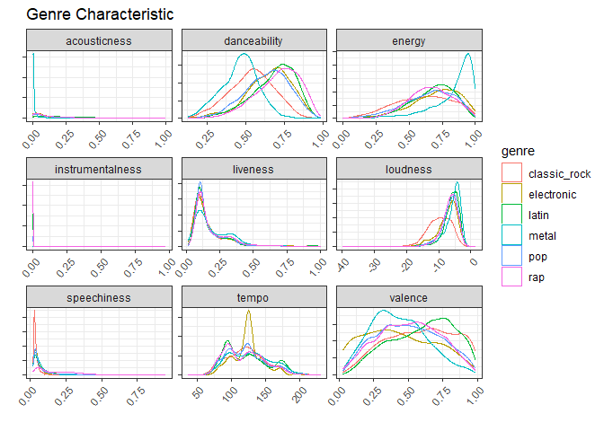

```r
    audio_features <- all_genre_top_artist %>%
      select(top.song)

    # Unnest della colonna top.song a livello superiore
    audio_features <- unnest(audio_features, top.song)

    # Eliminazione di colonne rindondanti (che posso causare anche collisioni con il
    # prossimo unnest)
    audio_features <- audio_features %>%
      select(genre, name, popularity, explicit, song.features)

    # Unnest della colonna song.features a livello superiore (data-frame allo stesso livello)
    audio_features <- unnest(audio_features, song.features)

    # Creazione nuova colonna duration_s (conversione della colonna duration_ms in secondi)
    audio_features <- audio_features %>%
      mutate(duration_s = map(duration_ms, function(x){x/1000}))

    # Assegnazione tipo numerico alla nuova colonna duration_s
    audio_features$duration_s <- as.numeric(audio_features$duration_s)


  # Analisi caratteristiche di ogni genere

    # Creazione data-frame per visualizzazione delle caratteristiche di ogni genere
    temp <- names(audio_features)[c(5, 6, 8, 10:15)]

    genre_analysis <- audio_features %>%
      select(c("genre", temp)) %>%
      pivot_longer(cols = temp, values_transform = as.numeric)

    # Creazione grafico
    genre_analysis %>%
      ggplot(aes(x = value)) +
      geom_density(aes(color = genre)) +
      facet_wrap(~name, ncol = 3, scales = 'free') +
      labs(title = 'Genre Characteristic',x = '', y = '') +
      theme_bw() +
      theme(axis.text.x = element_text(angle = 50, hjust = 1),axis.text.y = element_blank())
```

Da questa prima analisi possiamo già evincere alcuni aspetti fondamentali:

- le canzoni metal sono molto energiche e hanno un volume complessivo della traccia molto alto
- tutti i generi si presentato più ballabili del metal e del rock
- la positività è più o meno distribuita equamente (salvo metal in cui è concentrato maggiormente su valori bassi
- la musica elettronica è concentrata in un piccolo range di BPM, a differenza degli altri generi che sono più distribuiti

Osservazione: gli elementi appena elencati sono quelli che contribuiscono maggiormente a differenziare un genere da un altro. Fattori come l’acustica, la strumentalità, la presenza di parole e la probabilità che il brano sia suonato in live è molto simile per tutti i generi.

## Caratteristiche medie dei generi

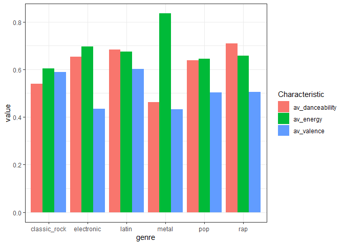

```r
# Creazione data-frame per visualizzazione delle caratteristiche generali di ogni genere
    genre_analysis_average <- audio_features %>%
      group_by(genre) %>%
      nest() %>%
      mutate(av_duration = map(data, function(x){mean(x$duration_s, na.rm = TRUE)})) %>%
      mutate(av_energy = map(data, function(x){mean(x$energy, na.rm = TRUE)})) %>%
      mutate(av_tempo = map(data, function(x){mean(x$tempo, na.rm = TRUE)})) %>%
      mutate(av_danceability = map(data, function(x){mean(x$danceability, na.rm = TRUE)})) %>%
      mutate(av_valence = map(data, function(x){mean(x$valence, na.rm = TRUE)})) %>%
      select(-data, -av_duration, -av_tempo)

    # Gathering data-frame (portare le variabili a valori)
    genre_analysis_average <- gather(genre_analysis_average, 'av_energy', 'av_danceability',
                                     'av_valence', key = "Characteristic",
                                     value = "value")

    # Riordinamento data-frame per genere
    genre_analysis_average <- genre_analysis_average %>%
      arrange(genre)

    # Assegnazione tipo numerico alla colonna value
    genre_analysis_average$value <- as.numeric(genre_analysis_average$value)

    # Creazione grafico
    ggplot(genre_analysis_average, aes(fill=Characteristic, y=value, x=genre)) +
      geom_bar(position="dodge", stat="identity") +
      theme_bw()
```

## Correlazione tra variabili

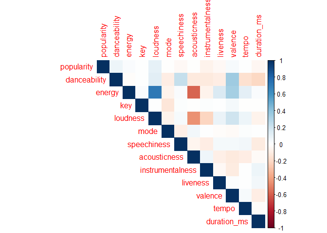

```r
    genre_characteristic <- audio_features %>%
      ungroup() %>%
      select(popularity, danceability, energy, key, loudness, mode, speechiness,acousticness,
             instrumentalness, liveness, valence, tempo, duration_ms)

    # Visualizzazione data-frame con corrplot
    corrplot(cor(genre_characteristic, use="pairwise.complete.obs"),
             method = "color",
             type = "upper",
             order = "original")
```

Possiamo notare che esiste:

Un’interessante correlazione può essere quella della popolarità rispetto a tutte le altre caratteristiche: non c’è un fattore tale per cui esiste una forte correlazione tra i due: gli unici che emergono leggermente dagli altri sono il **livello di volume** e la **danzabilità**.

# Analisi della popolarità delle canzoni

## Caratteristiche delle canzoni più famose

```r
# Creazione data-frame con le 200 canzoni più popolari
    top_200_song <- audio_features %>%
      select(popularity, danceability, energy, key, loudness, mode, speechiness,acousticness,
             instrumentalness, liveness, valence, tempo, duration_s) %>%
      arrange(desc(popularity)) %>%
      head(200)
```

### Genere delle 200 canzoni più popolari a livello mondiale

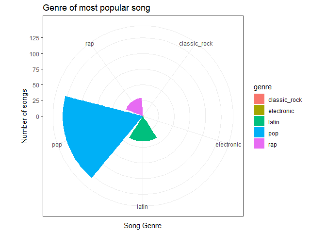

```r
    top_200_song %>%
      count(genre) %>%
      ggplot() +
      geom_col(aes(x = genre, y = n, fill = genre)) +
      coord_polar() +
      theme_bw() +
      theme(axis.text.x = element_text(hjust = 1), axis.text.y = element_text(hjust = 1)) +
      ggtitle("Genre of most popular song") +
      xlab("Song Genre") +
      ylab("Number of songs")
```

Selezionando dal data-set di 18340 canzoni a livello mondiale le prime 200 canzoni in base alla popolarità, si riscontra subito che il genere con maggior numero di brani è il pop, seguito dalla musica latina, dal hip-hop e infine dal rock e la musica elettronica in minima parte. Il metal non compare in classifica.

### Caratteristiche delle canzoni più famose

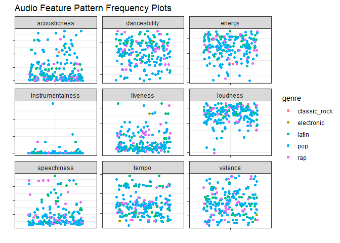

```r
temp3 <- names(top_200_song)[c(3,4,6,8:13)]

    top_200_analysis <- top_200_song %>%
      select(c("genre", temp3)) %>%
      pivot_longer(cols = temp3)

    # Grafico che mostra le caratteristiche delle canzoni più popolari
    top_200_analysis %>%
      ggplot(aes(x = name, y = value)) +
      geom_jitter(aes(color = genre)) +
      facet_wrap(~name, ncol = 3, scales = 'free') +
      labs(title = 'Audio Feature Pattern Frequency Plots', x = '', y = '') +
      theme_bw()+
      theme(axis.text.y = element_blank(), axis.text.x = element_blank())
```

In base al grafico a dispersione si evince che le canzoni più popolari sono:

- poco acustiche
- generalmente danzabili
- con un alto livello di energia
- quasi tutte non puramente strumentali
- generalmente registrate senza pubblico
- con alto livello di volume
- con una presenza di parole piuttosto bassa
- con tempo e positività piuttosto distribuiti

### Durata canzoni più popolari

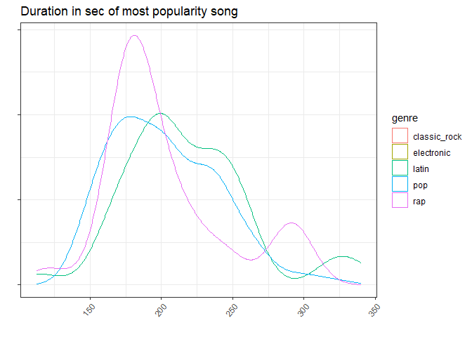

```r
# Grafico
    ggplot(data = top_200_song, mapping = aes(x = duration_s)) +
      geom_density(aes(color = genre)) +
      labs(title = 'Duration in sec of most popularity song',x = '', y = '') +
      theme_bw() +
      theme(axis.text.x = element_text(angle = 50, hjust = 1),axis.text.y = element_blank())
```

Studiando la durata delle canzoni più popolari si ricava che:

- il rap ha un’alta concentrazione tra i 150s e 210s, che risale leggermente tra 290s e 320s
- il pop è più distribuito, variando dai 150s ai 275s
- la musica latina come il pop è maggiormente distribuita con valori più alti, da 170s a 280s

La lunghezza ideale di una canzone destinata a diventare virale si aggira quindi in un range di 150 e 250s secondi.

### Tonalità canzoni più popolari

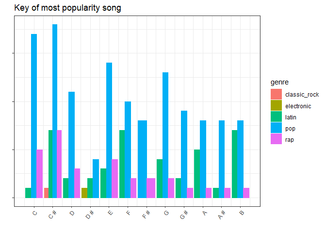

```r
# Grafico
    ggplot(data = top_200_song, mapping = aes(x = key, fill = genre)) +
      geom_bar(aes(color = genre), position="dodge") +
      labs(title = 'Key of most popularity song',x = '', y = '') +
      theme_bw() +
      scale_x_continuous(breaks = 0:11, labels = c("C", "C #", "D", "D #", "E", "F",
                                                   "F #", "G", "G #", "A", "A #", "B")) +
      theme(axis.text.x = element_text(angle = 50, hjust = 1), axis.text.y = element_blank())
```

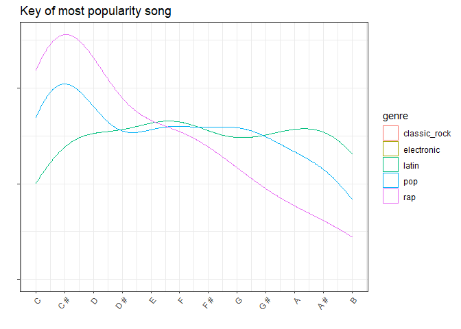

```r
    ggplot(data = top_200_song, mapping = aes(x = key)) +
      geom_density(aes(color = genre)) +
      labs(title = 'Key of most popularity song',x = '', y = '') +
      theme_bw() +
      scale_x_continuous(breaks = 0:11, labels = c("C", "C #", "D", "D #", "E", "F",
                                                   "F #", "G", "G #", "A", "A #", "B")) +
      theme(axis.text.x = element_text(angle = 50, hjust = 1), axis.text.y = element_blank())
```

## Top 10 canzoni a livello mondiale

```r
# Data-frame
    top_10_song <- all_genre_top_artist %>%
      select(genre, name, top.song)

    colnames(top_10_song)[2] <- "artist.name"

    top_10_song <- unnest(top_10_song, top.song)

    top_10_song <- top_10_song %>%
      arrange(desc(popularity))

    top_10_song <- top_10_song[!duplicated(top_10_song$name), ]

    top_10_song <- top_10_song %>%
      head(10) %>%
      select(-id, -track_number, -album.id, -album.name,
             -album.total_tracks, -album.type, -duration_ms)

    top_10_song <- unnest(top_10_song, song.features)

    # Creazione nuova colonna duration_s (conversione della
    # colonna duration_ms in secondi)
    top_10_song <- top_10_song %>%
      mutate(duration_s = map(duration_ms, function(x){x/1000}))

    # Assegnazione tipo numerico alla nuova colonna duration_s
    top_10_song$duration_s <- as.numeric(top_10_song$duration_s)
```

| Nome Canzone | Nome Artista | Genere | Popolarità |
| --- | --- | --- | --- |
| Quevedo: Bzrp Music Sessions, Vol. 52 | Bizarrap | pop | 100 |
| Me Porto Bonito | Bad Bunny | latin | 99 |
| Tití Me Preguntó | Bad Bunny | latin | 97 |
| Efecto | Bad Bunny | latin | 96 |
| Glimpse of Us | Joji | pop | 96 |
| Ojitos Lindos | Bomba Estéreo | pop | 96 |
| Moscow Mule | Bad Bunny | latin | 95 |
| Left and Right (Feat. Jung Kook of BTS) | BTS | pop | 94 |
| PROVENZA | KAROL G | latin | 94 |
| As it was | Harry Styles | pop | 93 |

### Acustica

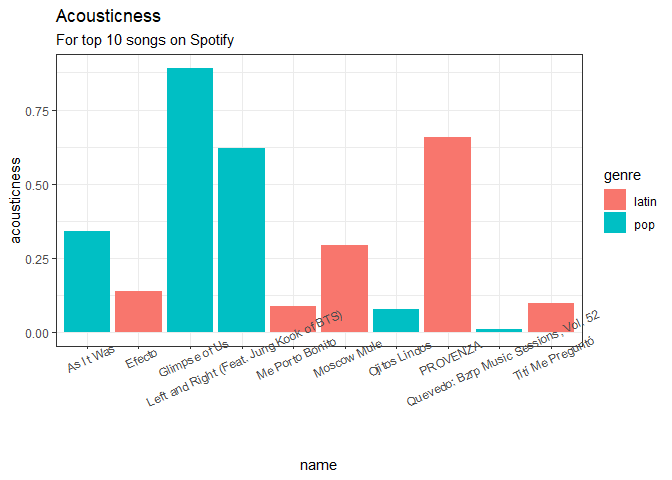

```r
    ggplot(data = top_10_song, mapping = aes(x = name, y = acousticness,
                                             fill = genre, shape = genre)) +
      geom_col() +
      theme_bw() +
      theme(axis.text.x = element_text(angle = 25, hjust = 0.5)) +
      ggtitle('Acousticness', subtitle = 'For top 10 songs on Spotify')
```

Esiste una forte diversità di acustica tra le top 10 canzoni a livello mondiale

### Livello del volume

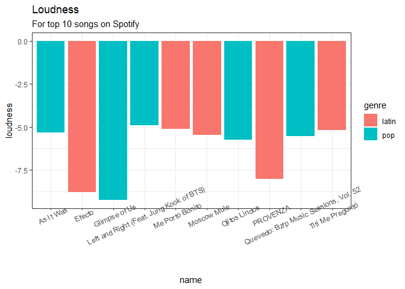

```r
    ggplot(data = top_10_song, mapping = aes(x = name, y = loudness,
                                             fill = genre, shape = genre)) +
      geom_col() +
      theme_bw() +
      theme(axis.text.x = element_text(angle = 25, hjust = 0.5)) +
      ggtitle('Loudness', subtitle = 'For top 10 songs on Spotify')
```

### Positività

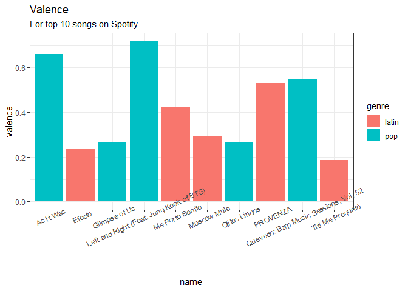

```r
ggplot(data = top_10_song, mapping = aes(x = name, y = valence,
                                         fill = genre, shape = genre)) +
      geom_col() +
      theme_bw() +
      theme(axis.text.x = element_text(angle = 25, hjust = 0.5)) +
      ggtitle('Valence', subtitle = 'For top 10 songs on Spotify')
```

### Danzabilità

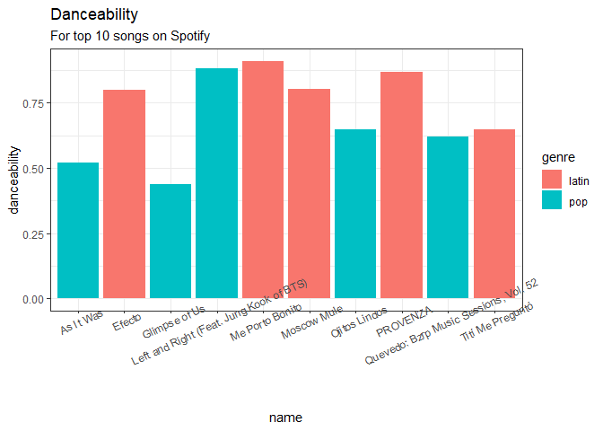

```r
    ggplot(data = top_10_song, mapping = aes(x = name, y = danceability,
                                             fill = genre, shape = genre)) +
      geom_col() +
      theme_bw() +
      theme(axis.text.x = element_text(angle = 25, hjust = 0.5)) +
      ggtitle('Danceability', subtitle = 'For top 10 songs on Spotify')
```

## Top 10 artisti a livello mondiale

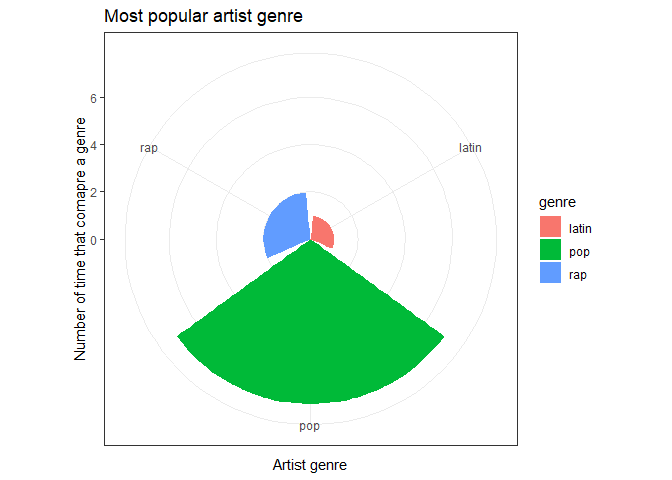

```r
  # Data-frame

    top_10_artist <- all_genre_top_artist %>%
      arrange(desc(popularity)) %>%
      head(10)

  # Analisi top 10 artisti

    top_10_artist %>%
      count(genre) %>%
      ggplot() +
      geom_col(aes(x = genre, y = n, fill = genre)) +
      coord_polar() +
      theme_bw() +
      theme(axis.text.x = element_text(hjust = 1),
            axis.text.y = element_text(hjust = 1)) +
      ggtitle("Most popular artist genre") +
      xlab("Artist genre") +
      ylab("Number of time that comapre a genre")
```

Come per le canzoni pop, gli artisti pop sono molto più famosi rispetto agli altri generi. Interessante però vedere che anche se le loro canzoni non appaiono attualmente in top 10, sono gli artisti rap ad essere più famosi di quelli di musica latina.

# Come fare una canzone popolare

E’ giunto il momento di fare un po di considerazioni e rispondere alla domanda iniziale: quali sono gli ingredienti di una canzone di successo, in grado di arrivare fino alle vette delle classifiche mondiali?  
Dalle analisi appena fatte, possiamo dire che:

- Sicuramente i generi più popolari al giorno d’oggi sono il pop, la musica latina e l’hip-hop (tentare di sfondare con canzoni di tipo metal o rock ha una bassissima probabilità di riuscita)
- Cercare di produrre un brano con un elevato livello di energia, livello del volume e danzabilità aumenta di parecchio le possibilità che diventi virale
- E’ quasi necessario che ci sia la presenza di voci nella traccia (che quindi non ci sia solo la parte strumentale) in modo tale che gli ascoltatori possano cantare e aumentare le probabilità di riascolto dello stesso brano nel lungo periodo
- Mantenere un range di durata della canzone tra i 150s e 250s è molto più conveniente rispetto a canzoni che durano più di 5 minuti (con canzoni più corte si aumenta anche la possibilità di passare in radio aumentando il numero di persone che ascoltano la canzone)
- Non è necessario che la canzone sia positiva: anche le canzoni più tristi hanno la stessa popolarità
- In relazione al genere del brano, utilizzare i tipi di tonalità più usati potrebbe far risultare anche una nuova canzone molto familiare e di conseguenza far aumentare le possibilità che venga apprezzata

Queste dunque sono le caratteristiche che hanno le canzoni più popolari del momento: ovviamente i tempi cambiano e queste considerazioni sono molto diverse da quelle che avremmo ottenuto dalle stesse analisi 30 anni fa (in cui generi come il pop e l’hip-hop erano alle origini). Interessante sarebbe ripete lo studio tra qualche anno per vedere come si evolvono i generi e i gusti della gente.

Back to top